# Risk Factor Analysis

## Outcome Variable

**Outcome Variable:** haz

## Predictor Variables

**Intervention Variable:** nhh

**Adjustment Set:**

unadjusted

## Stratifying Variables

The analysis was stratified on these variable(s):

- agecat
- studyid
- country

## Data Summary

| agecat | studyid | country | nhh | n_cell | n |
| --- | --- | --- | --- | --- | --- |
| Birth | IRC | INDIA | 3 or less | 54 | 388 |
| Birth | IRC | INDIA | 4-5 | 150 | 388 |
| Birth | IRC | INDIA | 6-7 | 103 | 388 |
| Birth | IRC | INDIA | 8+ | 81 | 388 |
| Birth | NIH-Birth | BANGLADESH | 3 or less | 112 | 608 |
| Birth | NIH-Birth | BANGLADESH | 4-5 | 255 | 608 |
| Birth | NIH-Birth | BANGLADESH | 6-7 | 138 | 608 |
| Birth | NIH-Birth | BANGLADESH | 8+ | 103 | 608 |
| Birth | NIH-Crypto | BANGLADESH | 3 or less | 108 | 732 |
| Birth | NIH-Crypto | BANGLADESH | 4-5 | 328 | 732 |
| Birth | NIH-Crypto | BANGLADESH | 6-7 | 176 | 732 |
| Birth | NIH-Crypto | BANGLADESH | 8+ | 120 | 732 |
| Birth | PROVIDE | BANGLADESH | 3 or less | 104 | 539 |
| Birth | PROVIDE | BANGLADESH | 4-5 | 251 | 539 |
| Birth | PROVIDE | BANGLADESH | 6-7 | 116 | 539 |
| Birth | PROVIDE | BANGLADESH | 8+ | 68 | 539 |
| 6 months | IRC | INDIA | 3 or less | 58 | 407 |
| 6 months | IRC | INDIA | 4-5 | 158 | 407 |
| 6 months | IRC | INDIA | 6-7 | 106 | 407 |
| 6 months | IRC | INDIA | 8+ | 85 | 407 |
| 6 months | LCNI-5 | MALAWI | 3 or less | 224 | 816 |
| 6 months | LCNI-5 | MALAWI | 4-5 | 340 | 816 |
| 6 months | LCNI-5 | MALAWI | 6-7 | 182 | 816 |
| 6 months | LCNI-5 | MALAWI | 8+ | 70 | 816 |
| 6 months | NIH-Birth | BANGLADESH | 3 or less | 95 | 537 |
| 6 months | NIH-Birth | BANGLADESH | 4-5 | 227 | 537 |
| 6 months | NIH-Birth | BANGLADESH | 6-7 | 128 | 537 |
| 6 months | NIH-Birth | BANGLADESH | 8+ | 87 | 537 |
| 6 months | NIH-Crypto | BANGLADESH | 3 or less | 104 | 715 |
| 6 months | NIH-Crypto | BANGLADESH | 4-5 | 326 | 715 |
| 6 months | NIH-Crypto | BANGLADESH | 6-7 | 170 | 715 |
| 6 months | NIH-Crypto | BANGLADESH | 8+ | 115 | 715 |
| 6 months | PROVIDE | BANGLADESH | 3 or less | 105 | 604 |
| 6 months | PROVIDE | BANGLADESH | 4-5 | 289 | 604 |
| 6 months | PROVIDE | BANGLADESH | 6-7 | 130 | 604 |
| 6 months | PROVIDE | BANGLADESH | 8+ | 80 | 604 |
| 6 months | SAS-FoodSuppl | INDIA | 3 or less | 33 | 380 |
| 6 months | SAS-FoodSuppl | INDIA | 4-5 | 166 | 380 |
| 6 months | SAS-FoodSuppl | INDIA | 6-7 | 115 | 380 |
| 6 months | SAS-FoodSuppl | INDIA | 8+ | 66 | 380 |
| 24 months | IRC | INDIA | 3 or less | 58 | 409 |
| 24 months | IRC | INDIA | 4-5 | 158 | 409 |
| 24 months | IRC | INDIA | 6-7 | 107 | 409 |
| 24 months | IRC | INDIA | 8+ | 86 | 409 |
| 24 months | LCNI-5 | MALAWI | 3 or less | 159 | 574 |
| 24 months | LCNI-5 | MALAWI | 4-5 | 237 | 574 |
| 24 months | LCNI-5 | MALAWI | 6-7 | 129 | 574 |
| 24 months | LCNI-5 | MALAWI | 8+ | 49 | 574 |
| 24 months | NIH-Birth | BANGLADESH | 3 or less | 75 | 429 |
| 24 months | NIH-Birth | BANGLADESH | 4-5 | 184 | 429 |
| 24 months | NIH-Birth | BANGLADESH | 6-7 | 100 | 429 |
| 24 months | NIH-Birth | BANGLADESH | 8+ | 70 | 429 |
| 24 months | NIH-Crypto | BANGLADESH | 3 or less | 69 | 514 |
| 24 months | NIH-Crypto | BANGLADESH | 4-5 | 232 | 514 |
| 24 months | NIH-Crypto | BANGLADESH | 6-7 | 130 | 514 |
| 24 months | NIH-Crypto | BANGLADESH | 8+ | 83 | 514 |
| 24 months | PROVIDE | BANGLADESH | 3 or less | 106 | 578 |
| 24 months | PROVIDE | BANGLADESH | 4-5 | 273 | 578 |
| 24 months | PROVIDE | BANGLADESH | 6-7 | 117 | 578 |
| 24 months | PROVIDE | BANGLADESH | 8+ | 82 | 578 |

The following strata were considered:

- agecat: 24 months, studyid: IRC, country: INDIA
- agecat: 24 months, studyid: LCNI-5, country: MALAWI
- agecat: 24 months, studyid: NIH-Birth, country: BANGLADESH
- agecat: 24 months, studyid: NIH-Crypto, country: BANGLADESH
- agecat: 24 months, studyid: PROVIDE, country: BANGLADESH
- agecat: 6 months, studyid: IRC, country: INDIA
- agecat: 6 months, studyid: LCNI-5, country: MALAWI
- agecat: 6 months, studyid: NIH-Birth, country: BANGLADESH
- agecat: 6 months, studyid: NIH-Crypto, country: BANGLADESH
- agecat: 6 months, studyid: PROVIDE, country: BANGLADESH
- agecat: 6 months, studyid: SAS-FoodSuppl, country: INDIA
- agecat: Birth, studyid: IRC, country: INDIA
- agecat: Birth, studyid: NIH-Birth, country: BANGLADESH
- agecat: Birth, studyid: NIH-Crypto, country: BANGLADESH
- agecat: Birth, studyid: PROVIDE, country: BANGLADESH

## Methods Detail

We’re interested in the causal parameters $E[Y_a]$ for all values of $a \in \mathcal{A}$. These parameters represent the mean outcome if, possibly contrary to fact, we intervened to set all units to have $A=a$. Under the randomization and positivity assumptions, these are identified by the statistical parameters $\psi_a=E_W[E_{Y|A,W}(Y|A=a,W)]$. In addition, we’re interested in the mean of $Y$, $E[Y]$ under no intervention (the observed mean). We will estimate these parameters by using SuperLearner to fit the relevant likelihood factors – $E_{Y|A,W}(Y|A=a,W)$ and $p(A=a|W)$, and then updating our likelihood fit using a joint TMLE.

For unadjusted analyses ($W=\{\}$), initial likelihoods were estimated using Lrnr_glm to estimate the simple $E(Y|A)$ and Lrnr_mean to estimate $p(A)$. For adjusted analyses, a small library containing Lrnr_glmnet, Lrnr_xgboost, and Lrnr_mean was used.

Having estimated these parameters, we will then use the delta method to estimate relative risks and attributable risks relative to a prespecified baseline level of $A$.

# Results Detail

## Results Plots

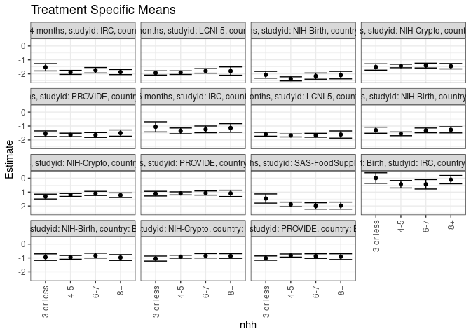

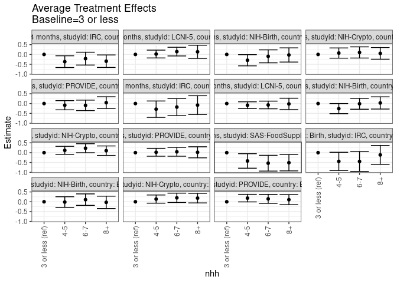

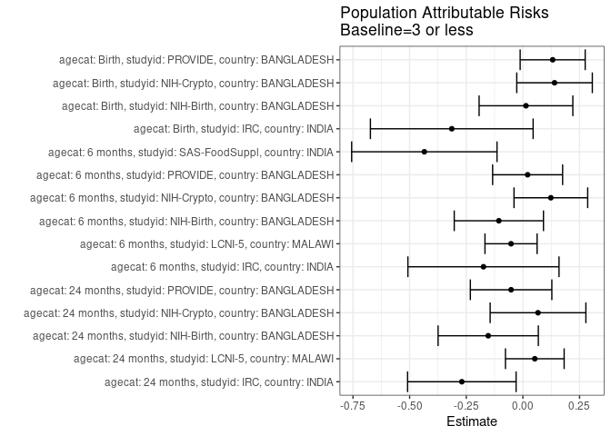

## Results Table

### Parameter: TSM

| agecat | studyid | country | intervention_level | baseline_level | estimate | ci_lower | ci_upper |
| --- | --- | --- | --- | --- | --- | --- | --- |
| Birth | IRC | INDIA | 3 or less | NA | 0.0059259 | -0.3720952 | 0.3839471 |
| Birth | IRC | INDIA | 4-5 | NA | -0.4374000 | -0.7051558 | -0.1696442 |
| Birth | IRC | INDIA | 6-7 | NA | -0.4412621 | -0.7811504 | -0.1013739 |
| Birth | IRC | INDIA | 8+ | NA | -0.1083951 | -0.4070486 | 0.1902585 |
| Birth | NIH-Birth | BANGLADESH | 3 or less | NA | -0.9445536 | -1.1796984 | -0.7094087 |
| Birth | NIH-Birth | BANGLADESH | 4-5 | NA | -0.9593725 | -1.0937436 | -0.8250015 |
| Birth | NIH-Birth | BANGLADESH | 6-7 | NA | -0.8360145 | -1.0091715 | -0.6628575 |
| Birth | NIH-Birth | BANGLADESH | 8+ | NA | -0.9733981 | -1.1826745 | -0.7641216 |
| Birth | NIH-Crypto | BANGLADESH | 3 or less | NA | -1.0491667 | -1.2286160 | -0.8697174 |
| Birth | NIH-Crypto | BANGLADESH | 4-5 | NA | -0.9126524 | -1.0178079 | -0.8074969 |
| Birth | NIH-Crypto | BANGLADESH | 6-7 | NA | -0.8491477 | -1.0063776 | -0.6919179 |
| Birth | NIH-Crypto | BANGLADESH | 8+ | NA | -0.8636667 | -1.0287235 | -0.6986098 |
| Birth | PROVIDE | BANGLADESH | 3 or less | NA | -1.0165385 | -1.1726870 | -0.8603899 |
| Birth | PROVIDE | BANGLADESH | 4-5 | NA | -0.8314741 | -0.9444084 | -0.7185398 |
| Birth | PROVIDE | BANGLADESH | 6-7 | NA | -0.8688793 | -1.0333010 | -0.7044576 |
| Birth | PROVIDE | BANGLADESH | 8+ | NA | -0.9097059 | -1.1148247 | -0.7045870 |
| 6 months | IRC | INDIA | 3 or less | NA | -1.0603161 | -1.4228026 | -0.6978296 |
| 6 months | IRC | INDIA | 4-5 | NA | -1.3470148 | -1.5529446 | -1.1410850 |
| 6 months | IRC | INDIA | 6-7 | NA | -1.2388836 | -1.4798291 | -0.9979382 |
| 6 months | IRC | INDIA | 8+ | NA | -1.1382941 | -1.4476886 | -0.8288996 |
| 6 months | LCNI-5 | MALAWI | 3 or less | NA | -1.5903125 | -1.7269478 | -1.4536772 |
| 6 months | LCNI-5 | MALAWI | 4-5 | NA | -1.6739706 | -1.7800476 | -1.5678936 |
| 6 months | LCNI-5 | MALAWI | 6-7 | NA | -1.6618681 | -1.8007284 | -1.5230078 |
| 6 months | LCNI-5 | MALAWI | 8+ | NA | -1.6085714 | -1.8654233 | -1.3517195 |
| 6 months | NIH-Birth | BANGLADESH | 3 or less | NA | -1.3012456 | -1.5199922 | -1.0824990 |
| 6 months | NIH-Birth | BANGLADESH | 4-5 | NA | -1.5579919 | -1.6941634 | -1.4218205 |
| 6 months | NIH-Birth | BANGLADESH | 6-7 | NA | -1.3121484 | -1.4827021 | -1.1415948 |
| 6 months | NIH-Birth | BANGLADESH | 8+ | NA | -1.2704215 | -1.4912353 | -1.0496076 |
| 6 months | NIH-Crypto | BANGLADESH | 3 or less | NA | -1.3220673 | -1.4955380 | -1.1485966 |
| 6 months | NIH-Crypto | BANGLADESH | 4-5 | NA | -1.2045706 | -1.3133029 | -1.0958382 |
| 6 months | NIH-Crypto | BANGLADESH | 6-7 | NA | -1.0960294 | -1.2448367 | -0.9472222 |
| 6 months | NIH-Crypto | BANGLADESH | 8+ | NA | -1.2221304 | -1.3898819 | -1.0543789 |
| 6 months | PROVIDE | BANGLADESH | 3 or less | NA | -1.1125238 | -1.2801448 | -0.9449029 |
| 6 months | PROVIDE | BANGLADESH | 4-5 | NA | -1.0937370 | -1.2032916 | -0.9841824 |
| 6 months | PROVIDE | BANGLADESH | 6-7 | NA | -1.0688205 | -1.2188822 | -0.9187589 |
| 6 months | PROVIDE | BANGLADESH | 8+ | NA | -1.0941250 | -1.3203703 | -0.8678797 |
| 6 months | SAS-FoodSuppl | INDIA | 3 or less | NA | -1.4636364 | -1.7938184 | -1.1334544 |
| 6 months | SAS-FoodSuppl | INDIA | 4-5 | NA | -1.8856627 | -2.0492713 | -1.7220540 |
| 6 months | SAS-FoodSuppl | INDIA | 6-7 | NA | -1.9990435 | -2.2267810 | -1.7713059 |
| 6 months | SAS-FoodSuppl | INDIA | 8+ | NA | -1.9740909 | -2.2268199 | -1.7213620 |
| 24 months | IRC | INDIA | 3 or less | NA | -1.5292816 | -1.7897071 | -1.2688561 |
| 24 months | IRC | INDIA | 4-5 | NA | -1.8960970 | -2.0410920 | -1.7511020 |
| 24 months | IRC | INDIA | 6-7 | NA | -1.7419315 | -1.9386135 | -1.5452494 |
| 24 months | IRC | INDIA | 8+ | NA | -1.8724612 | -2.0544624 | -1.6904601 |
| 24 months | LCNI-5 | MALAWI | 3 or less | NA | -1.9347799 | -2.0855522 | -1.7840075 |
| 24 months | LCNI-5 | MALAWI | 4-5 | NA | -1.9142194 | -2.0442668 | -1.7841720 |
| 24 months | LCNI-5 | MALAWI | 6-7 | NA | -1.7900775 | -1.9523653 | -1.6277898 |
| 24 months | LCNI-5 | MALAWI | 8+ | NA | -1.8000000 | -2.0993243 | -1.5006757 |
| 24 months | NIH-Birth | BANGLADESH | 3 or less | NA | -2.0660000 | -2.3089430 | -1.8230570 |
| 24 months | NIH-Birth | BANGLADESH | 4-5 | NA | -2.3611232 | -2.5087158 | -2.2135306 |
| 24 months | NIH-Birth | BANGLADESH | 6-7 | NA | -2.1615333 | -2.3836873 | -1.9393794 |
| 24 months | NIH-Birth | BANGLADESH | 8+ | NA | -2.0917976 | -2.3594231 | -1.8241721 |
| 24 months | NIH-Crypto | BANGLADESH | 3 or less | NA | -1.5079710 | -1.7348105 | -1.2811315 |
| 24 months | NIH-Crypto | BANGLADESH | 4-5 | NA | -1.4368966 | -1.5625404 | -1.3112527 |
| 24 months | NIH-Crypto | BANGLADESH | 6-7 | NA | -1.4059231 | -1.5777531 | -1.2340931 |
| 24 months | NIH-Crypto | BANGLADESH | 8+ | NA | -1.4533735 | -1.6450837 | -1.2616633 |
| 24 months | PROVIDE | BANGLADESH | 3 or less | NA | -1.5503302 | -1.7506093 | -1.3500511 |
| 24 months | PROVIDE | BANGLADESH | 4-5 | NA | -1.6352564 | -1.7572590 | -1.5132538 |
| 24 months | PROVIDE | BANGLADESH | 6-7 | NA | -1.6417949 | -1.8165063 | -1.4670834 |
| 24 months | PROVIDE | BANGLADESH | 8+ | NA | -1.5042683 | -1.7276170 | -1.2809196 |

### Parameter: E(Y)

| agecat | studyid | country | intervention_level | baseline_level | estimate | ci_lower | ci_upper |
| --- | --- | --- | --- | --- | --- | --- | --- |
| Birth | IRC | INDIA | NA | NA | -0.3080412 | -0.4687931 | -0.1472894 |
| Birth | NIH-Birth | BANGLADESH | NA | NA | -0.9310197 | -1.0197391 | -0.8423003 |
| Birth | NIH-Crypto | BANGLADESH | NA | NA | -0.9094945 | -0.9809370 | -0.8380521 |
| Birth | PROVIDE | BANGLADESH | NA | NA | -0.8851020 | -0.9601332 | -0.8100709 |
| 6 months | IRC | INDIA | NA | NA | -1.2344062 | -1.3658524 | -1.1029600 |
| 6 months | LCNI-5 | MALAWI | NA | NA | -1.6426961 | -1.7120603 | -1.5733318 |
| 6 months | NIH-Birth | BANGLADESH | NA | NA | -1.4073821 | -1.4960598 | -1.3187043 |
| 6 months | NIH-Crypto | BANGLADESH | NA | NA | -1.1986783 | -1.2700937 | -1.1272630 |
| 6 months | PROVIDE | BANGLADESH | NA | NA | -1.0916915 | -1.1661176 | -1.0172654 |
| 6 months | SAS-FoodSuppl | INDIA | NA | NA | -1.8986842 | -2.0118892 | -1.7854792 |
| 24 months | IRC | INDIA | NA | NA | -1.7987775 | -1.8923914 | -1.7051636 |
| 24 months | LCNI-5 | MALAWI | NA | NA | -1.8822648 | -1.9637218 | -1.8008078 |
| 24 months | NIH-Birth | BANGLADESH | NA | NA | -2.2190579 | -2.3217459 | -2.1163699 |
| 24 months | NIH-Crypto | BANGLADESH | NA | NA | -1.4412646 | -1.5249156 | -1.3576135 |
| 24 months | PROVIDE | BANGLADESH | NA | NA | -1.6024221 | -1.6857420 | -1.5191023 |

### Parameter: ATE

| agecat | studyid | country | intervention_level | baseline_level | estimate | ci_lower | ci_upper |
| --- | --- | --- | --- | --- | --- | --- | --- |
| Birth | IRC | INDIA | 3 or less | 3 or less | 0.0000000 | 0.0000000 | 0.0000000 |
| Birth | IRC | INDIA | 4-5 | 3 or less | -0.4433259 | -0.9065680 | 0.0199161 |
| Birth | IRC | INDIA | 6-7 | 3 or less | -0.4471881 | -0.9555423 | 0.0611662 |
| Birth | IRC | INDIA | 8+ | 3 or less | -0.1143210 | -0.5960823 | 0.3674403 |
| Birth | NIH-Birth | BANGLADESH | 3 or less | 3 or less | 0.0000000 | 0.0000000 | 0.0000000 |
| Birth | NIH-Birth | BANGLADESH | 4-5 | 3 or less | -0.0148190 | -0.2856486 | 0.2560106 |
| Birth | NIH-Birth | BANGLADESH | 6-7 | 3 or less | 0.1085391 | -0.1834822 | 0.4005604 |
| Birth | NIH-Birth | BANGLADESH | 8+ | 3 or less | -0.0288445 | -0.3436297 | 0.2859407 |
| Birth | NIH-Crypto | BANGLADESH | 3 or less | 3 or less | 0.0000000 | 0.0000000 | 0.0000000 |
| Birth | NIH-Crypto | BANGLADESH | 4-5 | 3 or less | 0.1365142 | -0.0714755 | 0.3445040 |
| Birth | NIH-Crypto | BANGLADESH | 6-7 | 3 or less | 0.2000189 | -0.0385670 | 0.4386049 |
| Birth | NIH-Crypto | BANGLADESH | 8+ | 3 or less | 0.1855000 | -0.0583151 | 0.4293151 |
| Birth | PROVIDE | BANGLADESH | 3 or less | 3 or less | 0.0000000 | 0.0000000 | 0.0000000 |
| Birth | PROVIDE | BANGLADESH | 4-5 | 3 or less | 0.1850644 | -0.0076440 | 0.3777727 |
| Birth | PROVIDE | BANGLADESH | 6-7 | 3 or less | 0.1476592 | -0.0790937 | 0.3744120 |
| Birth | PROVIDE | BANGLADESH | 8+ | 3 or less | 0.1068326 | -0.1509582 | 0.3646234 |
| 6 months | IRC | INDIA | 3 or less | 3 or less | 0.0000000 | 0.0000000 | 0.0000000 |
| 6 months | IRC | INDIA | 4-5 | 3 or less | -0.2866987 | -0.7035962 | 0.1301988 |
| 6 months | IRC | INDIA | 6-7 | 3 or less | -0.1785676 | -0.6138274 | 0.2566923 |
| 6 months | IRC | INDIA | 8+ | 3 or less | -0.0779780 | -0.5545506 | 0.3985945 |
| 6 months | LCNI-5 | MALAWI | 3 or less | 3 or less | 0.0000000 | 0.0000000 | 0.0000000 |
| 6 months | LCNI-5 | MALAWI | 4-5 | 3 or less | -0.0836581 | -0.2566365 | 0.0893204 |
| 6 months | LCNI-5 | MALAWI | 6-7 | 3 or less | -0.0715556 | -0.2663668 | 0.1232555 |
| 6 months | LCNI-5 | MALAWI | 8+ | 3 or less | -0.0182589 | -0.3091921 | 0.2726742 |
| 6 months | NIH-Birth | BANGLADESH | 3 or less | 3 or less | 0.0000000 | 0.0000000 | 0.0000000 |
| 6 months | NIH-Birth | BANGLADESH | 4-5 | 3 or less | -0.2567463 | -0.5144142 | 0.0009216 |
| 6 months | NIH-Birth | BANGLADESH | 6-7 | 3 or less | -0.0109028 | -0.2882810 | 0.2664753 |
| 6 months | NIH-Birth | BANGLADESH | 8+ | 3 or less | 0.0308242 | -0.2799955 | 0.3416438 |
| 6 months | NIH-Crypto | BANGLADESH | 3 or less | 3 or less | 0.0000000 | 0.0000000 | 0.0000000 |
| 6 months | NIH-Crypto | BANGLADESH | 4-5 | 3 or less | 0.1174968 | -0.0872343 | 0.3222278 |
| 6 months | NIH-Crypto | BANGLADESH | 6-7 | 3 or less | 0.2260379 | -0.0025134 | 0.4545892 |
| 6 months | NIH-Crypto | BANGLADESH | 8+ | 3 or less | 0.0999369 | -0.1413775 | 0.3412513 |
| 6 months | PROVIDE | BANGLADESH | 3 or less | 3 or less | 0.0000000 | 0.0000000 | 0.0000000 |
| 6 months | PROVIDE | BANGLADESH | 4-5 | 3 or less | 0.0187868 | -0.1814605 | 0.2190341 |
| 6 months | PROVIDE | BANGLADESH | 6-7 | 3 or less | 0.0437033 | -0.1812751 | 0.2686817 |
| 6 months | PROVIDE | BANGLADESH | 8+ | 3 or less | 0.0183988 | -0.2631748 | 0.2999724 |
| 6 months | SAS-FoodSuppl | INDIA | 3 or less | 3 or less | 0.0000000 | 0.0000000 | 0.0000000 |
| 6 months | SAS-FoodSuppl | INDIA | 4-5 | 3 or less | -0.4220263 | -0.7905204 | -0.0535321 |
| 6 months | SAS-FoodSuppl | INDIA | 6-7 | 3 or less | -0.5354071 | -0.9365113 | -0.1343030 |
| 6 months | SAS-FoodSuppl | INDIA | 8+ | 3 or less | -0.5104545 | -0.9262575 | -0.0946516 |
| 24 months | IRC | INDIA | 3 or less | 3 or less | 0.0000000 | 0.0000000 | 0.0000000 |
| 24 months | IRC | INDIA | 4-5 | 3 or less | -0.3668154 | -0.6648842 | -0.0687466 |
| 24 months | IRC | INDIA | 6-7 | 3 or less | -0.2126499 | -0.5390014 | 0.1137016 |
| 24 months | IRC | INDIA | 8+ | 3 or less | -0.3431796 | -0.6608994 | -0.0254598 |
| 24 months | LCNI-5 | MALAWI | 3 or less | 3 or less | 0.0000000 | 0.0000000 | 0.0000000 |
| 24 months | LCNI-5 | MALAWI | 4-5 | 3 or less | 0.0205605 | -0.1785491 | 0.2196700 |
| 24 months | LCNI-5 | MALAWI | 6-7 | 3 or less | 0.1447024 | -0.0768143 | 0.3662190 |
| 24 months | LCNI-5 | MALAWI | 8+ | 3 or less | 0.1347799 | -0.2003728 | 0.4699326 |
| 24 months | NIH-Birth | BANGLADESH | 3 or less | 3 or less | 0.0000000 | 0.0000000 | 0.0000000 |
| 24 months | NIH-Birth | BANGLADESH | 4-5 | 3 or less | -0.2951232 | -0.5793852 | -0.0108612 |
| 24 months | NIH-Birth | BANGLADESH | 6-7 | 3 or less | -0.0955333 | -0.4247349 | 0.2336682 |
| 24 months | NIH-Birth | BANGLADESH | 8+ | 3 or less | -0.0257976 | -0.3872457 | 0.3356504 |
| 24 months | NIH-Crypto | BANGLADESH | 3 or less | 3 or less | 0.0000000 | 0.0000000 | 0.0000000 |
| 24 months | NIH-Crypto | BANGLADESH | 4-5 | 3 or less | 0.0710745 | -0.1882372 | 0.3303861 |
| 24 months | NIH-Crypto | BANGLADESH | 6-7 | 3 or less | 0.1020479 | -0.1825250 | 0.3866208 |
| 24 months | NIH-Crypto | BANGLADESH | 8+ | 3 or less | 0.0545975 | -0.2424025 | 0.3515975 |
| 24 months | PROVIDE | BANGLADESH | 3 or less | 3 or less | 0.0000000 | 0.0000000 | 0.0000000 |
| 24 months | PROVIDE | BANGLADESH | 4-5 | 3 or less | -0.0849262 | -0.3194392 | 0.1495868 |
| 24 months | PROVIDE | BANGLADESH | 6-7 | 3 or less | -0.0914647 | -0.3572386 | 0.1743093 |
| 24 months | PROVIDE | BANGLADESH | 8+ | 3 or less | 0.0460619 | -0.2539320 | 0.3460558 |

### Parameter: PAR

| agecat | studyid | country | intervention_level | baseline_level | estimate | ci_lower | ci_upper |
| --- | --- | --- | --- | --- | --- | --- | --- |
| Birth | IRC | INDIA | 3 or less | NA | -0.3139672 | -0.6730840 | 0.0451496 |
| Birth | NIH-Birth | BANGLADESH | 3 or less | NA | 0.0135338 | -0.1933311 | 0.2203987 |
| Birth | NIH-Crypto | BANGLADESH | 3 or less | NA | 0.1396721 | -0.0270727 | 0.3064170 |
| Birth | PROVIDE | BANGLADESH | 3 or less | NA | 0.1314364 | -0.0121006 | 0.2749735 |
| 6 months | IRC | INDIA | 3 or less | NA | -0.1740901 | -0.5075942 | 0.1594139 |
| 6 months | LCNI-5 | MALAWI | 3 or less | NA | -0.0523836 | -0.1674090 | 0.0626418 |
| 6 months | NIH-Birth | BANGLADESH | 3 or less | NA | -0.1061364 | -0.3030720 | 0.0907991 |
| 6 months | NIH-Crypto | BANGLADESH | 3 or less | NA | 0.1233890 | -0.0392092 | 0.2859872 |
| 6 months | PROVIDE | BANGLADESH | 3 or less | NA | 0.0208323 | -0.1336581 | 0.1753227 |
| 6 months | SAS-FoodSuppl | INDIA | 3 or less | NA | -0.4350478 | -0.7558289 | -0.1142668 |
| 24 months | IRC | INDIA | 3 or less | NA | -0.2694959 | -0.5089736 | -0.0300182 |
| 24 months | LCNI-5 | MALAWI | 3 or less | NA | 0.0525151 | -0.0769982 | 0.1820284 |
| 24 months | NIH-Birth | BANGLADESH | 3 or less | NA | -0.1530579 | -0.3742576 | 0.0681418 |
| 24 months | NIH-Crypto | BANGLADESH | 3 or less | NA | 0.0667064 | -0.1445720 | 0.2779849 |
| 24 months | PROVIDE | BANGLADESH | 3 or less | NA | -0.0520920 | -0.2319298 | 0.1277459 |